# A Stage-Based Population Model for Loggerhead Sea Turtles, after Crouse, Crowder, and Caswell (1987)

Tamora James

15 November 2017

This workbook follows the matrix population model methods and analyses outlined in Crouse, Crowder, and Caswell (1987) to produce equivalent analyses.

First, import the turtle data (Crouse, Crowder, and Caswell 1987, Table 3) and add a column for stage length, then set up the projection matrix using this data and equations 1 and 2 in Crouse, Crowder, and Caswell (1987).

```r
turtleData <- read.csv("loggerhead_crouse1987.csv") %>%
    mutate(stage_length = max.age - min.age)

A <- with(turtleData, createProjectionMatrix(surv, fecund, stage_length))
print(A, digits=4)
```

```
##        [,1]    [,2]    [,3]    [,4]     [,5]   [,6]    [,7]
## [1,] 0.0000 0.00000 0.00000 0.00000 127.0000 4.0000 80.0000
## [2,] 0.6747 0.73711 0.00000 0.00000   0.0000 0.0000  0.0000
## [3,] 0.0000 0.04859 0.66105 0.00000   0.0000 0.0000  0.0000
## [4,] 0.0000 0.00000 0.01475 0.69067   0.0000 0.0000  0.0000
## [5,] 0.0000 0.00000 0.00000 0.05183   0.0000 0.0000  0.0000
## [6,] 0.0000 0.00000 0.00000 0.00000   0.8091 0.0000  0.0000
## [7,] 0.0000 0.00000 0.00000 0.00000   0.0000 0.8091  0.8088
```

Crouse, Crowder, and Caswell (1987) calculate the eigenvalues and eigenvectors using the power method. Here I’ll use just use eigen() to get the eigenvalues and vectors.

```r
eig <- eigen(A, symmetric = FALSE)
lambda <- Re(eig$values[1])
r <- log(lambda)
```

This gives $\lambda_m = 0.9452$ and $r = -0.0563$ which are pretty close to the values $\lambda_m = 0.9450$ and $r = -0.0565$ generated by Crouse, Crowder, and Caswell (1987).

The stable stage distribution is given by the right eigenvector (coerced here to its real part).

```r
w1 <- Re(eig$vectors[, 1])
turtleData <- mutate(turtleData, stage_dist = w1/sum(w1))
```

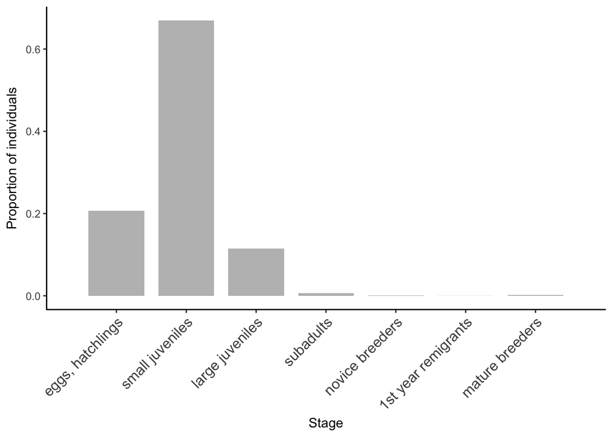

Most individuals belong to the eggs/hatchlings and small juvenile stages.

The reproductive value is given by the left eigenvector, which we get by calculating the eigenvectors of the transpose of the projection matrix.

```r
v1 <- eigen(t(A), symmetric = FALSE)$vectors[, 1]
turtleData <- mutate(turtleData, repro_val = Re(v1/v1[1]))
```

```
##                 class stage_dist repro_val
## 1    eggs, hatchlings   0.206577       1.0
## 2     small juveniles   0.669736       1.4
## 3     large juveniles   0.114529       6.0
## 4           subadults   0.006635     115.6
## 5     novice breeders   0.000364     567.8
## 6 1st year remigrants   0.000311     506.3
## 7     mature breeders   0.001848     586.6
```

The mean reproductive value can be calculated from the reproductive value and stable stage distribution.

```r
mean_repro <- with(turtleData, as.vector(Re(repro_val %*% stage_dist)))
print(mean_repro, digits = 4)
```

```
## [1] 4.047
```

## Sensitivity analyses

First, determine the impact of reducing or increasing fecundity or stage-specific survival parameters, each taken separately, on the intrinsic rate of increase $r$.

```r
perm <- rbind(c(1, 0), cbind(F = 0, S = 1:7))
sens_grow <- t(apply(perm, MARGIN = 1, function(x) {
    td <- turtleData %>% mutate(surv_dec = ifelse(stage == x["S"], surv * 0.5,
        surv), fecund_dec = ifelse(x["F"], 0.5, 1) * fecund, surv_inc = ifelse(stage ==
        x["S"], 0.99, surv), fecund_inc = ifelse(x["F"], 2, 1) * fecund)
    A <- with(td, createProjectionMatrix(surv_dec, fecund_dec, stage_length))
    eig <- eigen(A, symmetric = FALSE)
    r_dec <- Re(log(eig$values[1]))
    A <- with(td, createProjectionMatrix(surv_inc, fecund_inc, stage_length))
    eig <- eigen(A, symmetric = FALSE)
    r_inc <- Re(log(eig$values[1]))
    return(c(grow_dec = r_dec, grow_inc = r_inc))
}))
sens_grow <- data.frame(perm, sens_grow)
```

The first plot represents 50% reduction in fecundity or survivorship while the second plot represents a doubling in fecundity or elimination of mortality. The dotted lines in these plots indicate the baseline rate of increase.

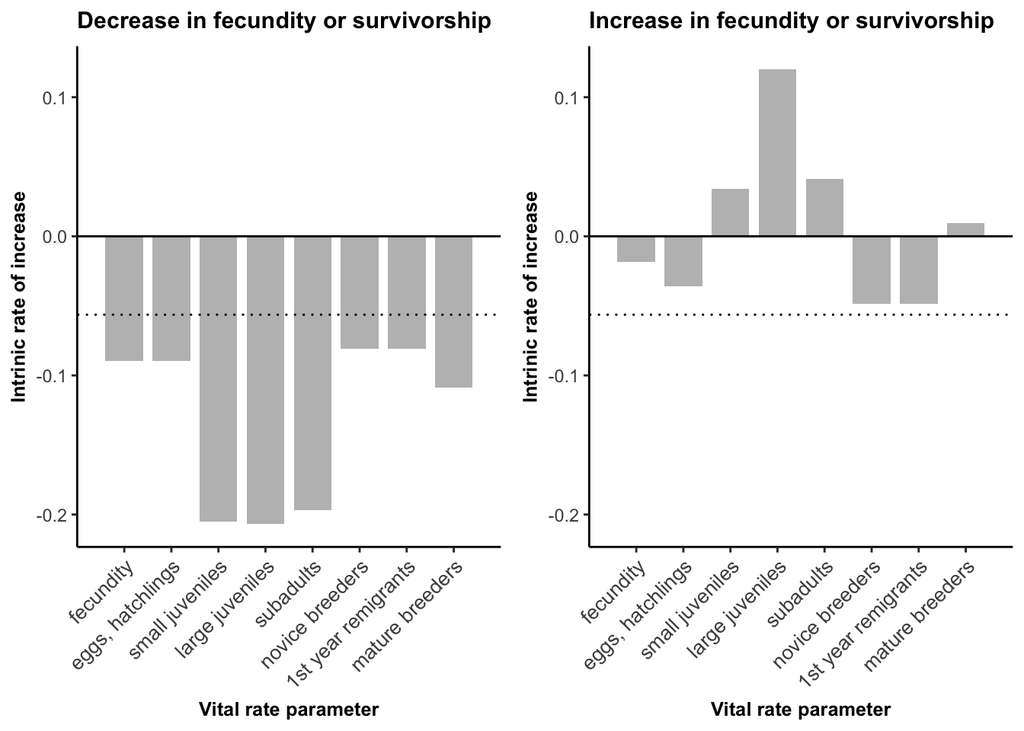

### Sensitivity to age at first reproduction

```r
ages <- seq(-2, 2, by = 1)
stages <- 2:4
sens_age <- sapply(ages, function(x) {
    td <- turtleData %>% mutate(stage_length = ifelse(stage %in% stages, stage_length +
        x, stage_length))
    A <- with(td, createProjectionMatrix(surv, fecund, stage_length))
    eig <- eigen(A, symmetric = FALSE)
    r <- Re(log(eig$values[1]))
    return(r)
})
```

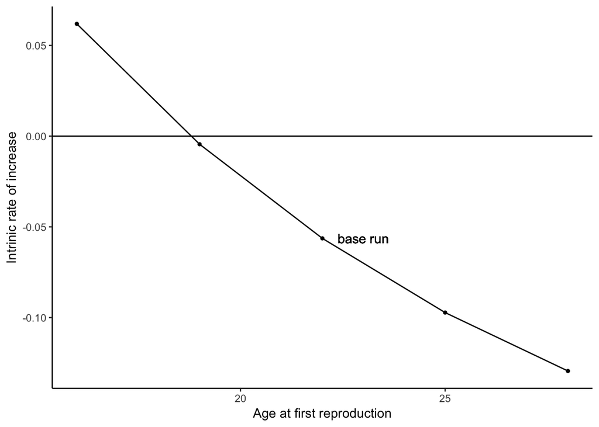

## Elasticity analysis

Analytical derivation of elacticities i.e. proportional sensitivities for matrix entries.

```r
S <- with(turtleData, Re(outer(repro_val, stage_dist))/mean_repro)
E <- (A/lambda) * S
```

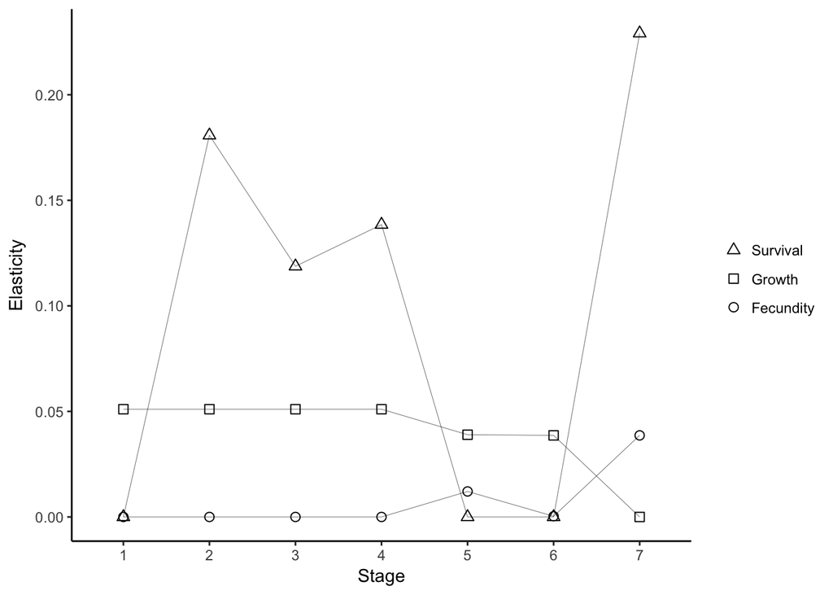

### Elasticity to stage-specific survival and stage duration

The figure below is obtained using calculations from Caswell (2001). The pattern is similar to the results in Crouse, Crowder, and Caswell (1987) but there are some small differences in pattern and the actual values don’t match.

The elasticity formulae in Caswell (2001) indicate how to calculate the elasticity of $\lambda$ to growth transition rather than stage duration so couldn’t be used to calculate elasticities to stage duration.

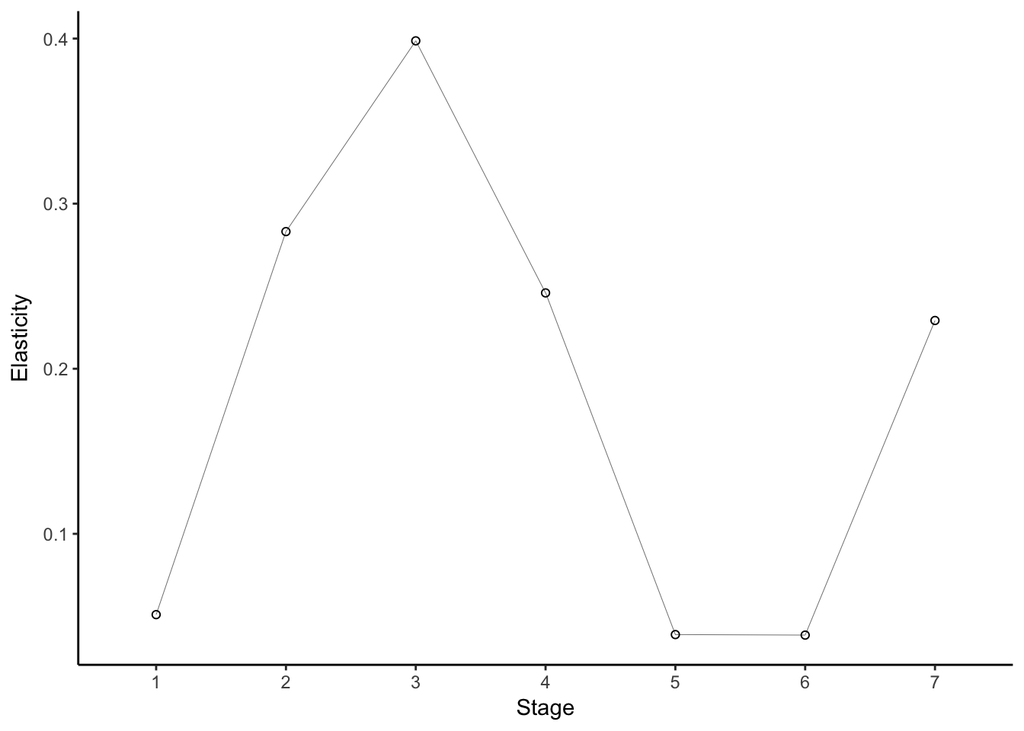

#### Elasticity of $\lambda$ to stage-specific survival and duration – alternative approach

Using the “brute force” approach of calculating the change in lambda resulting from a specified change in a vital rate. The sensitivity to the vital rate is the difference in lambda divided by the difference in the vital rate.

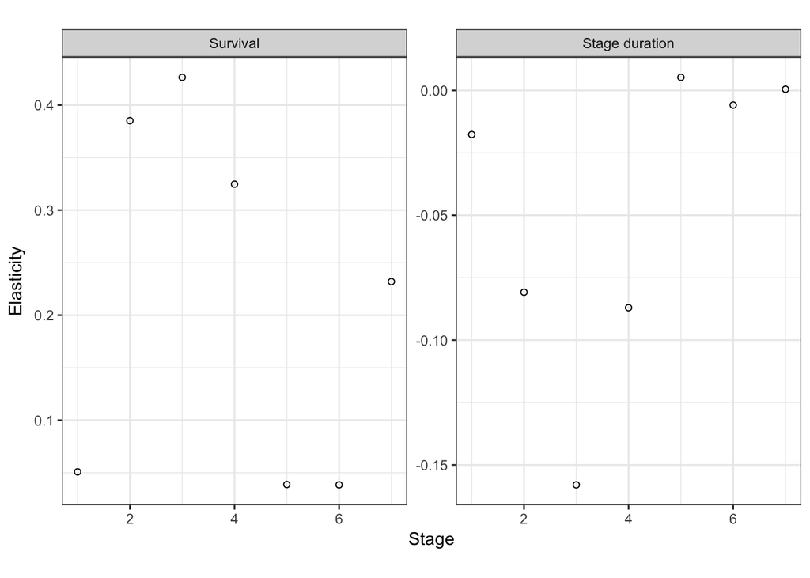

The pattern for elasticity to sensitivity and stage duration in stages 1, 5, 6, and 7 matches Crouse, Crowder, and Caswell (1987) but for stages 2–4 there is some discrepancy with the results reported in Crouse, Crowder, and Caswell (1987). Also, the elasticity values for survival don’t match those in Crouse, Crowder, and Caswell (1987).

## Management scenarios

Determine the rate of population growth expected under the following management scenarios:

1. Immature survivorship (stages 2, 3, and 4) increased to 0.80.
2. Survival of large juvenile and subadults increased to 0.80, adult survival increased to 0.85.
3. First-year survival decreased to 0.33735, survival of large juvenile and subadults increased to 0.80, adult survival increased to 0.85.

```r
td <- turtleData %>% mutate(surv_s1 = replace(surv, stage %in% 2:4, 0.8),
                            surv_s2 = ifelse(stage %in% 3:4, 0.8,
                                             ifelse(stage %in% 5:7, 0.85, surv)),
                            surv_s3 = ifelse(stage == 1, 0.5*surv,
                                             ifelse(stage %in% 3:4, 0.8,
                                                    ifelse(stage %in% 5:7, 0.85, surv))))

mod_s1 <- with(td, getMPM(surv_s1, fecund, stage_length))
mod_s2 <- with(td, getMPM(surv_s2, fecund, stage_length))
mod_s3 <- with(td, getMPM(surv_s3, fecund, stage_length))

lambdas <- c(mod_s1$lambda, mod_s2$lambda, mod_s3$lambda)
round(cbind(lambda=lambdas, r=log(lambdas)), digits=2)
```

```
##      lambda    r
## [1,]   1.06 0.06
## [2,]   1.06 0.06
## [3,]   1.02 0.02
```

What increase in survival at stages 2, 3, 4, and 7, taken individually, is required to achieve stability ($\lambda = 1$, $r = 0$)?

```r
stages <- c(2, 3, 4, 7)
tol <- 0.01
surv_final <- sapply(stages, function(x) {
    cand <- lower <- turtleData[x, "surv"]
    upper <- 1
    lambda <- 0
    while (lambda < 1 || upper - lower > tol) {
        cand <- (upper + lower)/2
        td <- turtleData %>% mutate(surv = replace(surv, stage == x, cand))
        mod <- with(td, getMPM(surv, fecund, stage_length))
        lambda <- mod$lambda
        if (lambda < 1) {
            lower <- cand
        }
        else {
            upper <- cand
        }
    }
    return(cand)
})
with(turtleData, round(rbind(surv_final, increase = surv_final/surv[stages]),
    digits = 3))
```

```
##             [,1]  [,2]  [,3]  [,4]
## surv_final 0.913 0.766 0.879 0.963
## increase   1.162 1.134 1.184 1.190
```

These results are slightly different to those of Crouse, Crowder, and Caswell (1987), probably due to using a different method of finding the stable point.

## References

Caswell, Hal. 2001. *Matrix Population Models: Construction, Analysis, and Interpretation*. 2nd ed. Sunderland, Mass.: Sinauer Associates.

Crouse, Deborah T., Larry B. Crowder, and Hal Caswell. 1987. “A Stage-Based Population Model for Loggerhead Sea Turtles and Implications for Conservation.” *Ecology* 68 (5): 1412–23. doi:10.2307/1939225.